# Working with ordinary differential equations in **pomp**

Aaron A. King

This lesson is based on notes developed over the years and contains contributions originally made by Ben Bolker, John Drake, Pej Rohani, and David Smith. It is [licensed under the Creative Commons Attribution-NonCommercial license](http://creativecommons.org/licenses/by-nc/4.0/). Please share and remix noncommercially, mentioning its origin.

**Important Note:** These materials have been updated for use with version 2.8. As of version 2, **pomp** syntax has changed substantially. These changes [are documented](http://kingaa.github.io/pomp/vignettes/upgrade_guide.html) on the **pomp** website.

Here we begin our study of computational techniques for studying epidemiological models. In this lesson we introduce the numerical solution (or integration) of nonlinear differential equations using the sophisticated solvers incorporated into **pomp**. Numerical integration is one of the most important tools we have for the analysis of epidemiological models.

### The SIR model

The classical SIR compartmental model divides a population of hosts into three classes: susceptible, infected, recovered. The model describes how the portion of the population in each of these classes changes with time. Births are modeled as flows from “elsewhere” into the susceptible class; deaths are modeled as flows from the S, I, or R compartment into “elsewhere”. If $S$, $I$, and $R$ refer to the numbers of individuals in each compartment, then these **state variables** change according to the following system of differential equations:
$$\begin{aligned}
\frac{dS}{dt} &= B-\lambda\,S-\mu\,S\\
\frac{dI}{dt} &= \lambda\,S-\gamma\,I-\mu\,I\\
\frac{dR}{dt} &= \gamma\,I-\mu\,R.\\
\end{aligned}$$
Here, $B$ is the crude birth rate (births per unit time), $\mu$ is the death rate and $\gamma$ is the recovery rate. We’ll assume that the force of infection, $\lambda$, has the form
$$\lambda = \beta\,\frac{I}{N},$$
so that the risk of infection a susceptible faces is proportional to the *prevalence* (the fraction of the population that is infected). This is known as the assumption of frequency-dependent transmission.

### Numerical integration of ordinary differential equations

Like almost all ecological and epidemiological models, one can’t solve these equations analytically. However, we can compute the **trajectories** of a continuous-time model such as this one by integrating the equations numerically. Doing this accurately involves a lot of calculation, and there are smart ways and not-so-smart ways of going about it. This very common problem has been very thoroughly studied by numerical analysts for generations so that, when the equations are smooth, well-behaved functions, excellent numerical integration algorithms are readily available to compute approximate solutions to high precision. In particular, **R** has several sophisticated ODE solvers which (for many problems) will give highly accurate solutions. These are harnessed by **pomp**. These algorithms are flexible, automatically perform checks, and give informative errors and warnings.

### SIR for a closed epidemic

Let’s study the SIR model for a closed population, i.e., one in which we can neglect births and deaths. Recall that the differential equations for the closed epidemic are
$$\begin{aligned}
\frac{dS}{dt} &= -\frac{\beta\,S\,I}{N}\\
\frac{dI}{dt} &= \frac{\beta\,S\,I}{N}-\gamma\,I\\
\frac{dR}{dt} &= \gamma\,I
\end{aligned}$$
To incorporate these deterministic equations into a `pomp` object, we supply them to the `pomp` function via the `skeleton` argument as a `Csnippet`. We must also provide a `Csnippet` to initialize the state variables $S$, $I$, and $R$. For example:

```r
library(pomp)

closed.sir.ode <- Csnippet("
  DS = -Beta*S*I/N;
  DI = Beta*S*I/N-gamma*I;
  DR = gamma*I;
")

init1 <- Csnippet("
  S = N-1;
  I = 1;
  R = 0;
  ")

pomp(data=data.frame(time=1:50,data=NA),
     times="time",t0=0,
     skeleton=vectorfield(closed.sir.ode),
     rinit=init1,
     statenames=c("S","I","R"),
     paramnames=c("Beta","gamma","N")) -> closed.sir
```

Now we can call `trajectory` to compute trajectories of the model. To do this, we’ll need some values of the parameters. If we’re thinking of a disease something like measles, and measuring time in days, we might use something like:

```r
params1 <- c(Beta=1,gamma=1/13,N=763)
```

What is the infectious period of this disease?

Next, we compute a model trajectory with the `trajectory` command and store the result in a data-frame:

```r
x <- trajectory(closed.sir,params=params1,format="data.frame")
```

and plot the results using the commands:

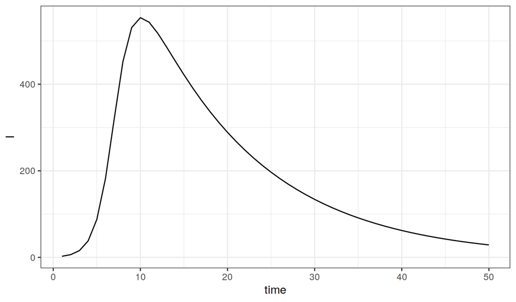

```r
library(ggplot2)
ggplot(data=x,mapping=aes(x=time,y=I))+geom_line()
```

#### Exercise: conversion of units

Suppose that you’d rather measure time in years. Modify the parameters accordingly and verify your modifications.

Let’s study how the epidemic curve depends on the transmission rate, $\beta$, and the infectious period. In particular, we’ll investigate how the epidemic curve changes as we vary $\beta$ from 0.05 to 2 and the infectious period from 1 to 8 days.

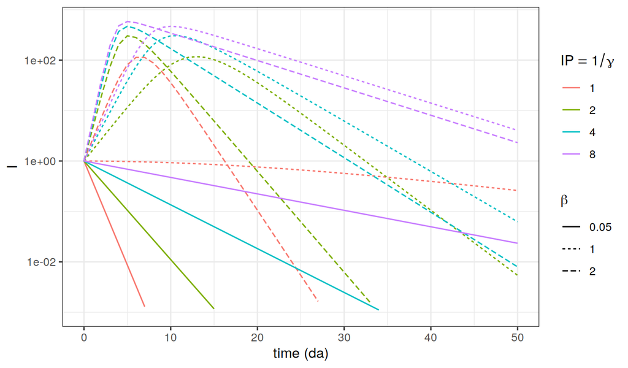

The ability to numerically integrate ODE is essential, but its power is limited. The next exercise demonstrates the importance of being able to analyze the equations as well.

#### Exercise: exploring the model’s dynamical repertoire

For each of the above parameter combinations, notice that either an epidemic occurs or the infection fades out. Can you predict this behavior from a knowledge of the parameters without numerically integrating the equations?

### The basic reproduction number

A dimensionless quantity of central importance in epidemiology is the so-called *basic reproduction number*, $R_0$, which is the expected number of new infections engendered by a single infected individual introduced into a fully susceptible population. In this case, $R_0=\frac{\beta}{\gamma}$, i.e., the product of the transmission rate and the infectious period. Compute $R_0$ for each of the parameter combinations you examined in the exercise above and relate it to the presence or absence of an epidemic.

### The epidemic final size

For a simple, closed SIR outbreak, we can derive an expression that determines the *final size* of the outbreak, i.e., the total number of hosts ultimately infected. To do this, note that if
$$\begin{equation*}\begin{gathered}
\frac{dS}{dt}=-\frac{\beta S I}{N} \qquad \text{and} \qquad
\frac{dI}{dt}=\frac{\beta S I}{N}-\gamma\,I,
\end{gathered}\end{equation*}$$
then
$$\frac{dI}{dS}=-1+\frac{N}{R_0\,S},$$
which we integrate to yield
$$S(0)-S(\infty)+\frac{N}{R_0}\,\log{\frac{S(\infty)}{S(0)}}=I(\infty)-I(0)=0.$$
If $S(0)=N$, then $N-S(\infty)$ is the final size of the outbreak and the fraction ultimately infected is $f=\frac{R(\infty)}{N}=1-\frac{S(\infty)}{N}$. In terms of the latter, we have
$$R_0=-\frac{\log{(1-f)}}{f}.$$

The following shows the relationship between final size and $R_0$:

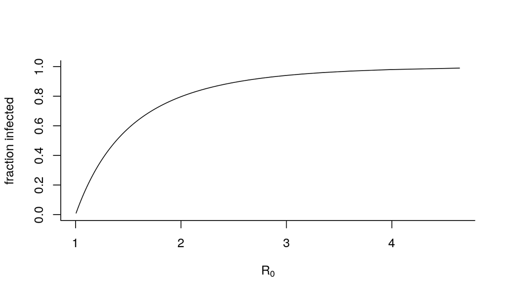

#### Exercise: final size

Use `trajectory` to study the dependence of $f$ on $R_0$. Compare your results with the predictions of the final size equation
$$R_0=-\frac{\log{(1-f)}}{f},$$
the solution of which is plotted above.

### SIR dynamics in an open population

Over a sufficiently short time scale, the assumption that the population is closed is reasonable. To capture the dynamics over the longer term, we’ll need to account for births and deaths, i.e., allow the population to be an **open** one. As we’ve seen, if we further assume that the birth rate equals the death rate, then the SIR equations become
$$\begin{aligned}
\frac{dS}{dt} &= \mu\,N-\frac{\beta\,S\,I}{N}-\mu\,S\\
\frac{dI}{dt} &= \frac{\beta\,S\,I}{N}-\gamma\,I-\mu\,I\\
\frac{dR}{dt} &= \gamma\,I-\mu\,R\\
\end{aligned}$$

We must modify the ODE function accordingly:

```r
open.sir.ode <- Csnippet("
  DS = -Beta*S*I/N+mu*(N-S);
  DI = Beta*S*I/N-gamma*I-mu*I;
  DR = gamma*I-mu*R;
")

init2 <- Csnippet("
  S = S_0;
  I = I_0;
  R = N-S_0-I_0;
")

pomp(data=data.frame(time=seq(0,20,by=1/52),cases=NA),
     times="time",t0=-1/52,
     skeleton=vectorfield(open.sir.ode),
     rinit=init2,
     statenames=c("S","I","R"),
     paramnames=c("Beta","gamma","mu","S_0","I_0","N")
) -> open.sir
```

We’ll need to specify a birth/death rate in addition to the two parameters we specified before:

```r
params3 <- c(mu=1/50,Beta=400,gamma=365/13,
  N=100000,S_0=100000/12,I_0=100)
```

We integrate the equations as before:

```r
x <- trajectory(open.sir,params=params3,format="d")
```

We can plot each of the state variables against time, and $I$ against $S$:

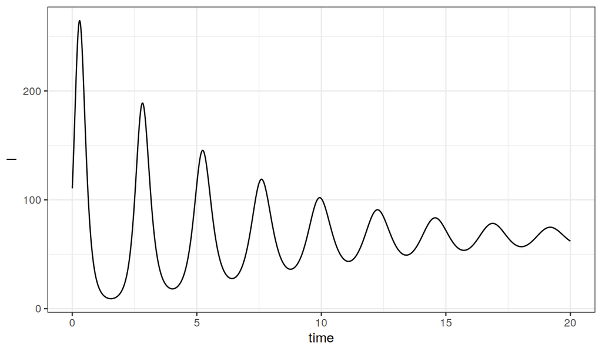

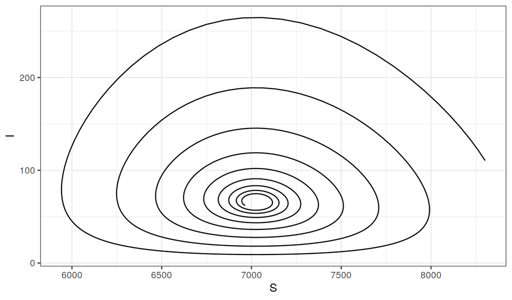

```r
library(ggplot2)
ggplot(data=x,mapping=aes(x=time,y=I))+geom_line()
ggplot(data=x,mapping=aes(x=S,y=I))+geom_path()
```

#### Exercise: exploring the model’s dynamical repertoire

Explore the dynamics of the system for different values of the $\beta$ and $\gamma$ parameters by simulating and plotting trajectories as time series and in phase space (e.g., $I$ vs. $S$). Use the same values of $\beta$ and $\gamma$ we looked at above. How does the value of $R_0$ affect the results?

#### Exercise: host lifespan

Under the assumptions of this model, the average host lifespan is $1/\mu$.  
Explore how host lifespan affects the dynamics by integrating the differential equations for lifespans of 20 and 200 years.

The compartmental modeling strategy can be put to use in modeling a tremendous range of infections. The following exercises make some first steps in this direction.

#### Exercise: SIRS model

The SIR model assumes lifelong sterilizing immunity following infection. For many infections, immunity is not permanent. Make a compartment diagram for an SIRS model, in which individuals lose their immunity after some time. Write the corresponding differential equations and modify the above codes to study its dynamics. Compare the SIR and SIRS dynamics for the parameters $\mu=1/50$, $\gamma=365/13$, $\beta=400$ and assuming that, in the SIRS model, immunity lasts for 10 years.

#### Exercise: SEIR model

Make a diagram, write the equations, and study the dynamics of the SEIR model for the dynamics of an infection with a latent period. Compare the dynamics of SIR and SEIR models for the parameters $\mu=1/50$, $\gamma=365/5$, $\beta=1000$ and assuming that, in the SEIR model, the latent period has duration 8 days.

### Nonautonomous equations

#### SIR with seasonal transmission

The simple SIR model always predicts damped oscillations towards an equilibrium (or pathogen extinction if $R_0$ is too small). This is at odds with the recurrent outbreaks seen in many real pathogens. Sustained oscillations require some additional drivers in the model. An important driver in childhood infections of humans (e.g., measles) is seasonality in contact rates because of aggregation of children the during school term. We can analyze the consequences of this by assuming sinusoidal forcing on $\beta$ according to $\beta(t)=\beta_0\,(1+\beta_1\cos(2\,\pi\,t))$. We can modify the code presented above to solve the equations for a seasonally forced epidemic.

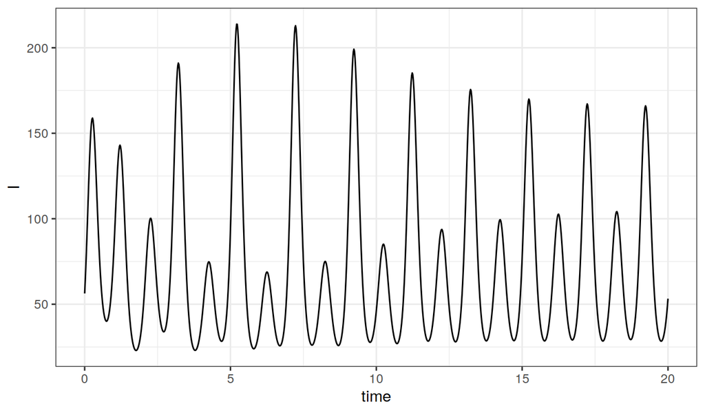

```r
seasonal.sir.ode <- Csnippet("
  double Beta = beta0*(1+beta1*cos(2*M_PI*t));
  DS = -Beta*S*I/N+mu*(N-S);
  DI = Beta*S*I/N-gamma*I-mu*I;
  DR = gamma*I-mu*R;
")

pomp(open.sir,
     skeleton=vectorfield(seasonal.sir.ode),
     rinit=init2,
     statenames=c("S","I","R"),
     paramnames=c("beta0","beta1","gamma","mu","N","S_0","I_0")
) -> seas.sir

params3 <- c(mu=1/50,beta0=400,beta1=0.15,gamma=26,
             N=1e5,S_0=7000,I_0=50)

trajectory(seas.sir,params=params3,format="data.frame") -> x

library(ggplot2)
ggplot(x,mapping=aes(x=time,y=I))+geom_path()
```

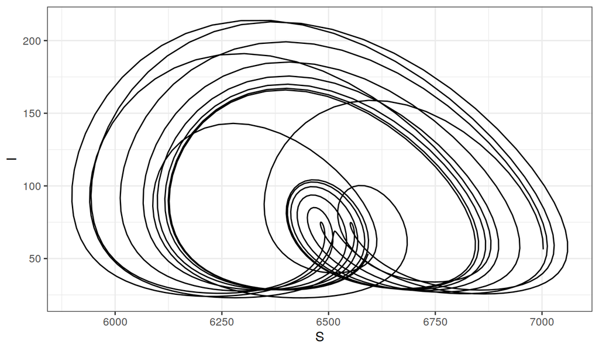

```r
ggplot(x,mapping=aes(x=S,y=I))+geom_path()
```

#### Exercise: exploration

Explore the dynamics of the seasonally forced SIR model for increasing amplitude $\beta_1$. Be sure to distinguish between transient and asymptotic dynamics.

## [Back to course homepage](http://kingaa.github.io/short-course)

## [**R** codes for this document](http://raw.githubusercontent.com/kingaa/short-course/master/parest/odes.R)